# Лабораторная работа №2

[output not shown]

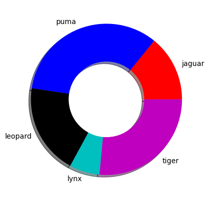

```python
# Круговая диаграмма с отверстием (кольцевая диаграмма)
vals = [24, 57, 33, 11, 45]
explode = (0.1, 0, 0.15, 0)
labels = ['jaguar', 'puma', 'leopard', 'lynx', 'tiger']
fig, ax = plt.subplots()
ax.pie(vals, colors = 'rbkcm', labels=labels, wedgeprops=dict(width=0.5), shadow=True)
```

```python
# Построение 3D-графиков.

import matplotlib.pyplot as plt
from mpl_toolkits.mplot3d import Axes3D
```

```
[<mpl_toolkits.mplot3d.art3d.Line3D at 0x213dae38670>]
```

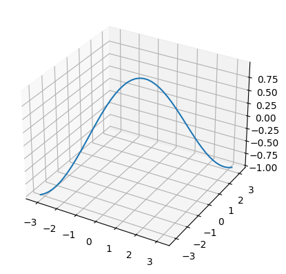

```python
# Линейный график
# Для построения линейного графика используется функция plot() из Axes3D

x = np.linspace(-np.pi, np.pi, 50)
y = x
z = np.cos(x)
fig = plt.figure()
ax = fig.add_subplot(111, projection='3d')
ax.plot(x, y, z, label='parametric curve')
```

```
[<mpl_toolkits.mplot3d.art3d.Line3D at 0x213daee9fd0>]
```

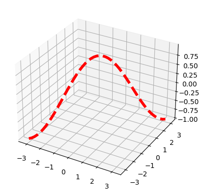

```python
# Линейный график
# Для построения линейного графика используется функция plot() из Axes3D

x = np.linspace(-np.pi, np.pi, 50)
y = x
z = np.cos(x)
fig = plt.figure()
ax = fig.add_subplot(111, projection='3d')
ax.plot(x, y, z, 'r--', lw = 4, label='parametric curve')
```

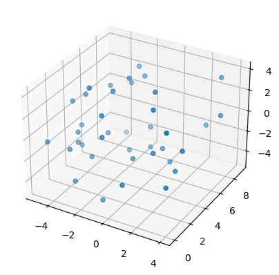

```python
# Точечный график (Диаграмма рассеяния)
# Для построения диаграммы рассеяния используется функция scatter() из Axes3D

np.random.seed(123)
x = np.random.randint(-5, 5, 40)
y = np.random.randint(0, 10, 40)
z = np.random.randint(-5, 5, 40)
fig = plt.figure()
ax = fig.add_subplot(111, projection='3d')
ax.scatter(x, y, z)
```

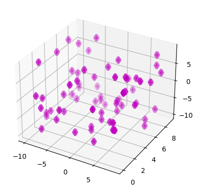

```python
# Точечный график (Диаграмма рассеяния)
# Для построения диаграммы рассеяния используется функция scatter() из Axes3D

np.random.seed(123)
x = np.random.randint(-10, 10, 70)
y = np.random.randint(0, 10, 70)
z = np.random.randint(-10, 10, 70)
fig = plt.figure()
ax = fig.add_subplot(111, projection='3d')
ax.scatter(x, y, z, depthshade=True, color = 'm', marker='d', lw = 5)
```

```
No artists with labels found to put in legend.  Note that artists whose label start with an underscore are ignored when legend() is called with no argument.
```

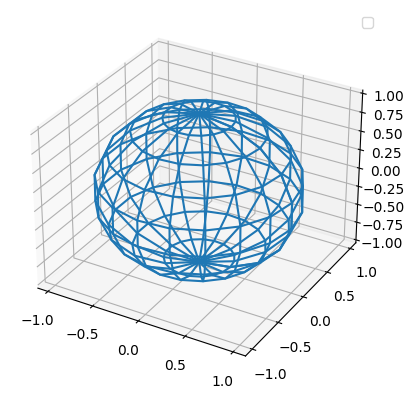

```python
# Каркасная поверхность
# Для построения каркасной поверхности используется функция plot_wireframe() из Axes3D

u, v = np.mgrid[0:2*np.pi:20j, 0:np.pi:10j]
x = np.cos(u)*np.sin(v)
y = np.sin(u)*np.sin(v)
z = np.cos(v)
fig = plt.figure()
ax = fig.add_subplot(111, projection='3d')
ax.plot_wireframe(x, y, z)
ax.legend()
```

```
No artists with labels found to put in legend.  Note that artists whose label start with an underscore are ignored when legend() is called with no argument.
```

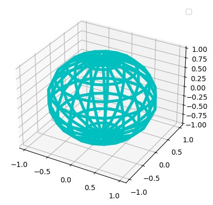

```python
# Каркасная поверхность
# Для построения каркасной поверхности используется функция plot_wireframe() из Axes3D

u, v = np.mgrid[0:2*np.pi:20j, 0:np.pi:10j]
x = np.cos(u)*np.sin(v)
y = np.sin(u)*np.sin(v)
z = np.cos(v)
fig = plt.figure()
ax = fig.add_subplot(111, projection='3d')
ax.plot_wireframe(x, y, z, color='c', lw = 4)
ax.legend()
```

```
No artists with labels found to put in legend.  Note that artists whose label start with an underscore are ignored when legend() is called with no argument.
```

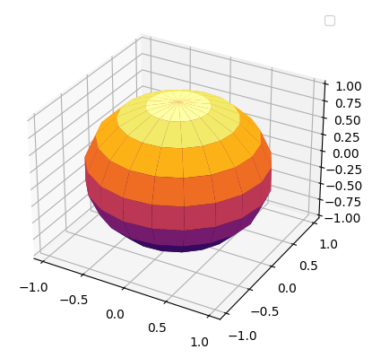

```python
# Поверхность
# Для построения поверхности используется функция plot_surface() из Axes3D

u, v = np.mgrid[0:2*np.pi:20j, 0:np.pi:10j]
x = np.cos(u)*np.sin(v)
y = np.sin(u)*np.sin(v)
z = np.cos(v)
fig = plt.figure()
ax = fig.add_subplot(111, projection='3d')
ax.plot_surface(x, y, z, cmap='inferno')
ax.legend()
```

```
No artists with labels found to put in legend.  Note that artists whose label start with an underscore are ignored when legend() is called with no argument.
```

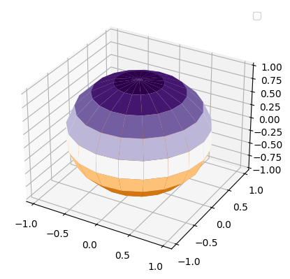

```python
# Поверхность
# Для построения поверхности используется функция plot_surface() из Axes3D

u, v = np.mgrid[0:2*np.pi:20j, 0:np.pi:10j]
x = np.cos(u)*np.sin(v)
y = np.sin(u)*np.sin(v)
z = np.cos(v)
fig = plt.figure()
ax = fig.add_subplot(111, projection='3d')
ax.plot_surface(x, y, z, cmap='PuOr')
ax.legend()
```

## Подключим датасет "Medicaid" для 2-ой части лабораторной работы

```python
#импортируем библиотеку Pandas для работы с табличными данными
import pandas as p
#открываем файл с данными
data = p.read_csv("Medicaid1986.csv", index_col = 0)
data
```

|  | visits | exposure | children | age | income | health1 | health2 | access | married | gender | ethnicity | school | enroll | program |
| --- | --- | --- | --- | --- | --- | --- | --- | --- | --- | --- | --- | --- | --- | --- |
| 1 | 0 | 100 | 1 | 24 | 14.500 | 0.495 | -0.854 | 0.50 | no | female | cauc | 13 | yes | afdc |
| 2 | 1 | 90 | 3 | 19 | 6.000 | 0.520 | -0.969 | 0.17 | no | female | cauc | 11 | yes | afdc |
| 3 | 0 | 106 | 4 | 17 | 8.377 | -1.227 | 0.317 | 0.42 | no | female | cauc | 12 | yes | afdc |
| 4 | 0 | 114 | 2 | 29 | 6.000 | -1.524 | 0.457 | 0.33 | no | female | cauc | 12 | yes | afdc |
| 5 | 11 | 115 | 1 | 26 | 8.500 | 0.173 | -0.599 | 0.67 | no | female | cauc | 16 | yes | afdc |
| ... | ... | ... | ... | ... | ... | ... | ... | ... | ... | ... | ... | ... | ... | ... |
| 992 | 0 | 106 | 0 | 65 | 8.500 | -2.264 | 0.347 | 0.33 | yes | male | cauc | 8 | no | ssi |
| 993 | 1 | 107 | 0 | 90 | 9.660 | 1.532 | 0.455 | 0.50 | yes | male | cauc | 0 | no | ssi |
| 994 | 10 | 116 | 1 | 70 | 6.000 | 2.660 | -0.723 | 0.17 | no | female | cauc | 8 | no | ssi |
| 995 | 3 | 118 | 0 | 73 | 6.000 | 0.813 | 0.056 | 0.17 | no | female | cauc | 12 | no | ssi |
| 996 | 0 | 115 | 2 | 71 | 10.444 | -2.113 | 0.236 | 0.42 | yes | male | other | 14 | no | ssi |

996 rows × 14 columns

#### Значения атрибутов:

1. visits: Посещения, кол-во посещений врача.
2. exposure: Воздействие,продолжительность периода наблюдения при амбулаторном лечении в днях.
3. children: Дети, общее количество детей в домохозяйстве.
4. age: Возраст, возраст испытуемого.
5. income: Доход, годовой доход домохозяйства (средний диапазон доходов в миллионах долларов США).
6. health1: 1-ый основной компонент деленный на 1000, трех состояний здоровья: функциональные ограничения, острые состояния и хронические состояния.
7. health2: 2-ой основной компонент деленный на 1000, трех состояний здоровья: функциональные ограничения, острые состояния и хронические состояния.
8. access: Доступность медицинских услуг от 0 до 1.
9. married: В браке, состоит ли этот человек в браке.
10. gender: Пол опрашиваемого.
11. ethnicity: Этническая принадлежность.
12. school: Количество лет, проведенных в обучении.
13. enroll: Зарегистрирован ли человек в демонстрационной программе.
14. program: Указывает на демонстрационную программу управляемого ухода: Помощь семьям с детьми-иждивенцами ("afdc") или неинституционализированный дополнительный доход по страхованию ("ssi").

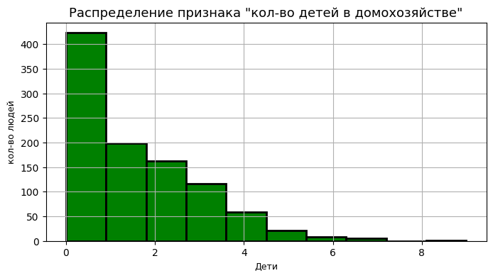

```python
plt.figure(figsize=(8, 4))
plt.hist(data['children'], color='green', edgecolor = 'black', linewidth = 2)
plt.title('Распределение признака "кол-во детей в домохозяйстве"', fontsize=13)
plt.xlabel("Дети", fontsize=9)
plt.ylabel("кол-во людей", fontsize=9)

plt.grid(True);
```

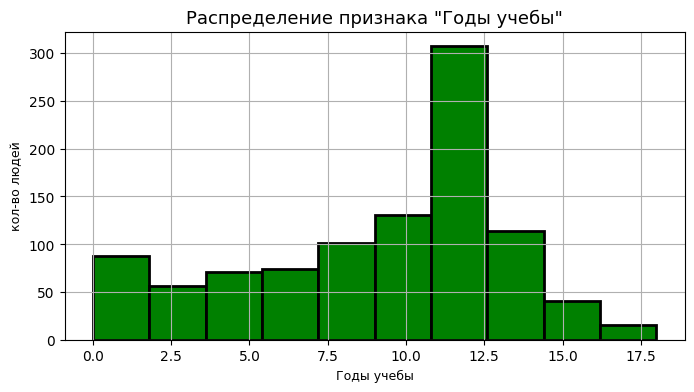

```python
plt.figure(figsize=(8, 4))
plt.hist(data['school'], color='green', edgecolor = 'black', linewidth = 2)
plt.title('Распределение признака "Годы учебы"', fontsize=13)
plt.xlabel("Годы учебы", fontsize=9)
plt.ylabel("кол-во людей", fontsize=9)

plt.grid(True);
```

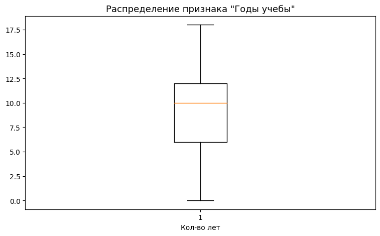

```python
plt.figure(figsize=(9, 5))
plt.boxplot(data['school'])
plt.title('Распределение признака "Годы учебы"', fontsize=13)
plt.xlabel("Кол-во лет", fontsize=10);
```

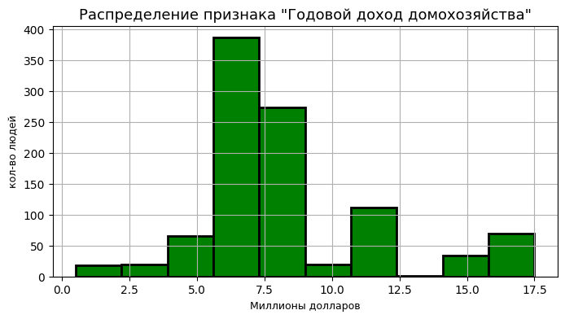

```python
plt.figure(figsize=(8, 4))
plt.hist(data['income'], color='green', edgecolor = 'black', linewidth = 2)
plt.title('Распределение признака "Годовой доход домохозяйства"', fontsize=13)
plt.xlabel("Миллионы долларов", fontsize=9)
plt.ylabel("кол-во людей", fontsize=9)

plt.grid(True);
```

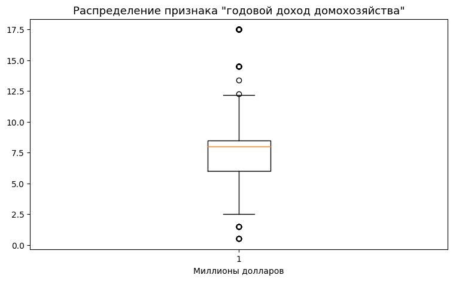

```python
plt.figure(figsize=(9, 5))
plt.boxplot(data['income'])
plt.title('Распределение признака "годовой доход домохозяйства"', fontsize=13)
plt.xlabel("Миллионы долларов", fontsize=10);
```

Вывод: имеются выбросы в признаке "income", большая часть домохозяйств получает в год от 6 до 8.5 миллионов долларов.

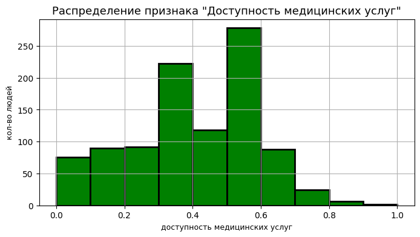

```python
plt.figure(figsize=(8, 4))
plt.hist(data['access'], color='green', edgecolor = 'black', linewidth = 2)
plt.title('Распределение признака "Доступность медицинских услуг"', fontsize=13)
plt.xlabel("доступность медицинских услуг", fontsize=9)
plt.ylabel("кол-во людей", fontsize=9)

plt.grid(True);
```

[figure not shown]

```python
data.groupby('children')['access'].agg(['count']).plot(kind='bar', figsize=(8, 5), color ='pink', width = 0.5, edgecolor = 'salmon', linewidth = 2)
plt.title('Доступность медицинских услуг по количество детей', fontsize=13)
plt.xlabel("Количество детей", fontsize=10)
plt.grid(True)
```

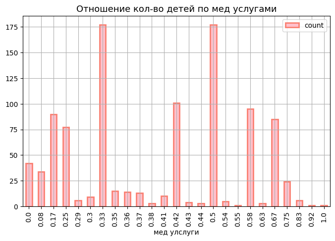

```python
data.groupby('access')['children'].agg(['count']).plot(kind='bar', figsize=(8, 5), color ='pink', width = 0.5, edgecolor = 'salmon', linewidth = 2)
plt.title('Отношение кол-во детей по мед услугами', fontsize=13)
plt.xlabel("мед улслуги", fontsize=10)
plt.grid(True)
```

Доступность медицинских услуг: 0 - низкий уровень, 1 - высокий уровень.

[figure not shown]

```python
plt.figure(figsize=(9, 5))
plt.boxplot(data['children'])
plt.title('Распределение признака "Доступность медицинских услуг"', fontsize=13)
plt.xlabel("Доступность медицинских услуг", fontsize=10);
```

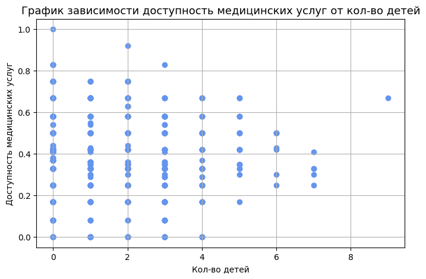

```python
plt.figure(figsize=(8, 5))
plt.scatter(data["children"], data["access"], color="cornflowerblue")
plt.title('График зависимости доступность медицинских услуг от кол-во детей', fontsize=13)
plt.xlabel("Кол-во детей", fontsize=10)
plt.ylabel("Доступность медицинских услуг", fontsize=10)
plt.grid(True)
```

[figure not shown]

```python
plt.figure(figsize=(8, 4))
plt.hist(data['visits'], color='green', edgecolor = 'black', linewidth = 2)
plt.title('Распределение признака "Доступность медицинских услуг"', fontsize=13)
plt.xlabel("доступность медицинских услуг", fontsize=9)
plt.ylabel("кол-во людей", fontsize=9)

plt.grid(True);
```

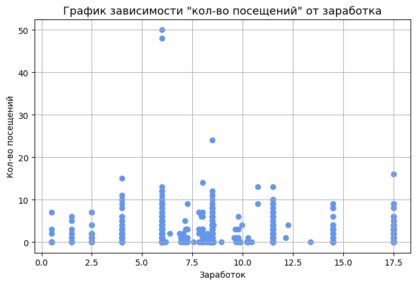

```python
plt.figure(figsize=(8, 5))
plt.scatter(data["income"], data["visits"], color="cornflowerblue")
plt.title('График зависимости "кол-во посещений" от заработка', fontsize=13)
plt.xlabel("Заработок", fontsize=10)
plt.ylabel("Кол-во посещений", fontsize=10)
plt.grid(True)
```

### Вывод: большинство людей которые зарабатывают 6 и 8 посещают больше, а от 6 до 8 больше не посещают.

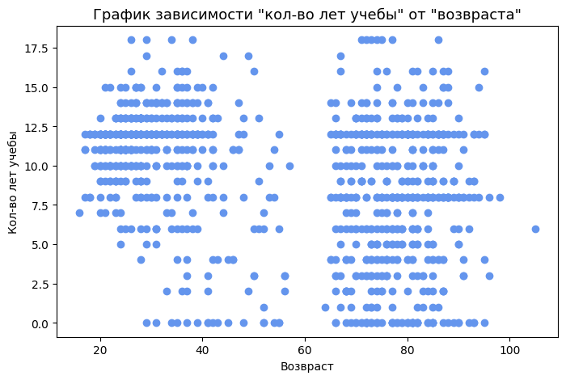

```python
plt.figure(figsize=(8, 5))
x = data['age']
y = data['school']
plt.scatter(x, y, color = 'cornflowerblue')
plt.title('График зависимости "кол-во лет учебы" от "возвраста"', fontsize=13)
plt.xlabel("Возвраст", fontsize=10)
plt.ylabel("Кол-во лет учебы", fontsize=10)
```

### Вывод: Люди от 20 до 60, гораздо дольше учились и имели образование, чем люди от 60 до 100

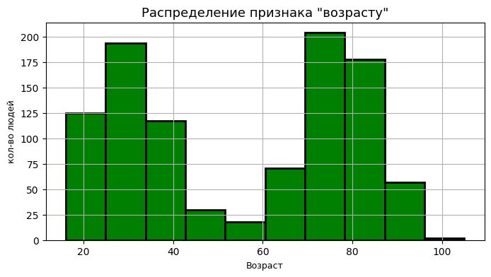

```python
plt.figure(figsize=(8, 4))
plt.hist(data['age'], color='green', edgecolor = 'black', linewidth = 2)
plt.title('Распределение признака "возрасту"', fontsize=13)
plt.xlabel("Возраст", fontsize=9)
plt.ylabel("кол-во людей", fontsize=9)

plt.grid(True);
```

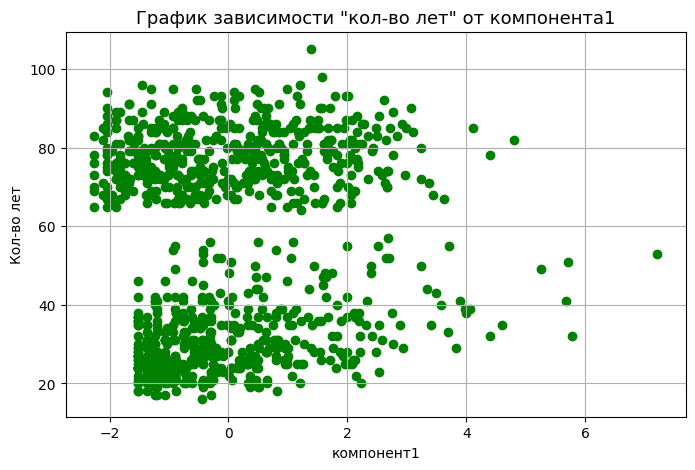

```python
plt.figure(figsize=(8, 5))
plt.scatter(data["health1"], data["age"], color="g")
plt.title('График зависимости "кол-во лет" от компонента1', fontsize=13)
plt.xlabel("компонент1", fontsize=10)
plt.ylabel("Кол-во лет", fontsize=10)
plt.grid(True)
```

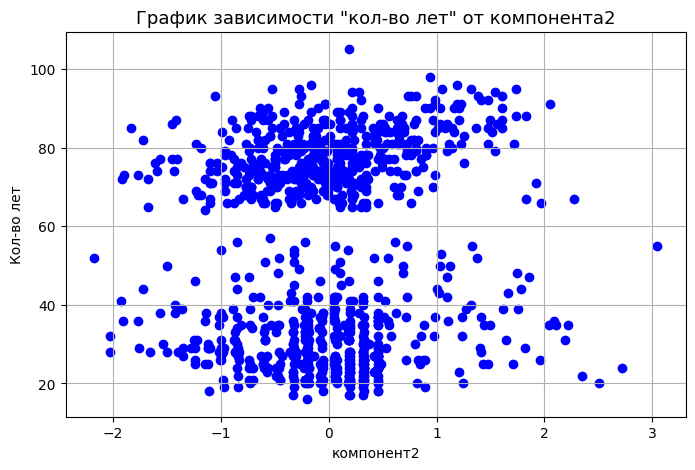

```python
plt.figure(figsize=(8, 5))
plt.scatter(data["health2"], data["age"], color="blue")
plt.title('График зависимости "кол-во лет" от компонента2', fontsize=13)
plt.xlabel("компонент2", fontsize=10)
plt.ylabel("Кол-во лет", fontsize=10)
plt.grid(True)
```

#### Вывод: 1 компонент хуже всего воспринимают люди от 60 лет, а 2 компонент все группы одинаково